# Mise à jour du COG - INSEE - Fichier des personnes décédées

# Le [Fichier des personnes décédées](https://www.data.gouv.fr/fr/datasets/fichier-des-personnes-decedees/)

Suite à l’avis favorable émis par la Commission d’accès aux documents administratifs (CADA) le 17 mai 2019[^1], le Fichier des personnes décédées — produit par l’INSEE à partir des enregistrements communaux depuis 1970 — est librement accessible depuis décembre 2019. Il contient les informations suivantes sur chaque personne décédée : le nom et le prénom, le sexe, la date de naissance, le code et le libellé de la commune (pour les personnes nées en France métropolitaine ou dans les DOM/TOM/COM) ou du pays de naissance (pour les personnes nées à l’étranger), la date du décès, le code de la commune de décès, et enfin le numéro d’acte de décès.

Les caractéristiques d’exhaustivité (ensemble des personnes décédées en France) et de désagrégation élevée tant sur le plan spatial (échelon communal), temporel (date au jour) que social (individu) des données ainsi que l’homogénéité et la stabilité de ses variables au cours du temps constituent des opportunités d’analyse certaines.

Sur Datagouv, le fichier des personnes décédées est disponible en tronçons annuels ou trimestriels. Une version concaténée et prête à l’emploi du fichier a été construite par C. Quest, et publiée à cette adresse sur Datagouv: http://data.cquest.org/insee_deces/

```r
# Chargement du jeu de données
insee_deces <- readr::read_csv("insee_deces.csv",
                               col_types = cols(code_lieu_deces = col_character(),
                                                code_lieu_naissance = col_character(),
                                                date_deces = col_date(format = "%Y-%m-%d"),
                                                date_naissance = col_character(),
                                                numero_acte_deces = col_character(),
                                                pays_naissance = col_character()))
# Retirer les doublons
insee_deces <- insee_deces[!duplicated(insee_deces),]
```

```
## [1] "Le fichier comporte 39337 COG uniques de naissance."
```

```
## [1] "Le fichier comporte 39424 COG uniques de décès."
```

Cependant, les variables indiquant les codes des communes de naissance et de décès nécessitent une étape préalable d’harmonisation avant d’être utilisées.

1. Le référentiel des codes commune utilisé dans le fichier n’est pas le même selon la date d’enregistrement du décès. La conversion des codes commune utilisés dans le référentiel 2020 permet de mettre à jour 923 915 enregistrements en ce qui concerne les lieux de naissance et 77 273 enregistrements en ce qui concerne les lieux de décès.
2. La prise en compte des collectivités d’outre-mer sous le régime de l’exception législative (absentes du COG 2020) et des modifications ayant affecté les codes de communes érigées en collectivités d’outre-mer dans les années 2000 permet de mettre à jour 26 637 enregistrements en ce qui concerne les lieux de naissance et 12173 enregistrements en ce qui concerne les lieux de décès.
3. L’harmonisation des codes faisant référence à des lieux situés à l’étranger concerne quant à elle 2 141 829 enregistrements pour les naissances et 189 321 enregistrements pour les décès.
4. Des erreurs d’enregistrement des codes communes existent et certaines peuvent être corrigées. Les corrections proposées ici permettent de mettre à jour l’ensemble des codes restés sans correspondance en ce qui concerne les lieux de naissance, soit 4 429 enregistrements. Par ailleurs, seuls 1 648 enregistrements restent sans correspondance en ce qui concerne les lieux de décès.

# 1. Harmoniser les codes géographiques

Le [Code Officiel Géographique](https://www.data.gouv.fr/fr/datasets/r/ac1b1ce7-63b4-4f90-9c41-a2b0adada388) (COG) est un document produit chaque année par l’Insee. Ce document rassemble les codes et libellés des communes, des cantons, des arrondissements, des départements, des régions et des pays et territoires étrangers au 1er janvier.

Alors que la plupart des jeux de données disponibles en libre accès sur le site de l’Institut National de la Statistique et des Etudes Economiques sont harmonisés, c’est-à-dire que les codes géographiques renseignés ont été convertis dans le Code Offciel Géographique le plus récent (c’est le cas des données du recensement notamment), ce n’est pas le cas des fichiers des personnes décédées. Au sein de ces derniers, les lieux de naissance et de décès des individus sont enregistrés dans le Code Officiel Géographique en vigueur au moment du décès. Aussi, dans le cadre d’une analyse diachronique tenant compte de la distribution géographique des naissances et des décès, il est nécessaire d’harmoniser ces informations, c’est-à-dire de tenir compte des modifications de la géographie communale survenues depuis le décès de sorte que tous les enregistrements de la base de données soient dans le même COG.

## Les modifications de la géographie communale française depuis 1970

Le découpage administratif des territoires français n’est pas stable dans le temps.

La [table des mouvements communaux](https://www.insee.fr/fr/statistiques/fichier/4316069/mvtcommune2020-csv.zip) permet de constater qu’entre le 1er janvier 1970 et le 1er janvier 2020, 10 921 évènements ont affecté la géographie communale française. Certaines communes ont changé de département (la Corse a été scindée en deux départements en 1976 par exemple) ce qui a entraîné la modification de leur code communal, d’autres ont fusionné ou défusionné.

```r
# Chargement de la table des mouvements communaux
mvtcommune <- readr::read_csv("mvtcommune2020.csv")
```

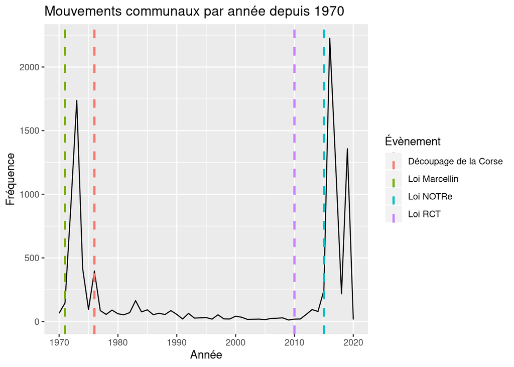

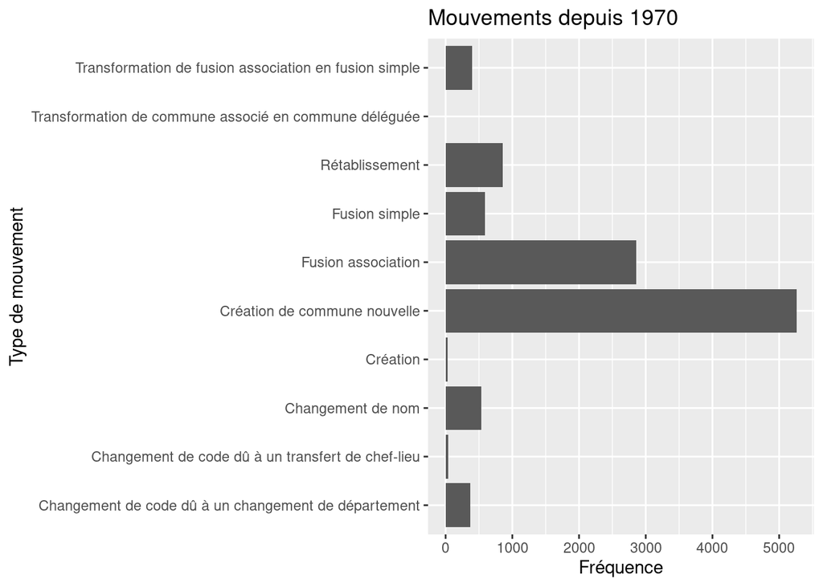

N.B.: Le package COGugaison spécialement développé pour harmoniser ces variables n’est pas utilisé car: - le référentiel le plus ancien utilisé par COGugaison date de 1968 et des codes commune en vigueur avant 1968 sont présents dans la base. - dans les cas où des communes auraient connu deux changements successifs dans une période inter-censitaire, l’harmonisation ne peut se faire automatiquement. - il est nécessaire de connaître le millésime de référence du code commune pour opérer sa transposition, or une partie des codes utilisés en date du décès correspondent à des référentiels périmés.